# Data Generation Exercise 4

## Disclaimer

Outline and documentation of how the data for exercise 4 are generated is given in this notebook.

## The Data

Different types of data are used for exercise 4. These types are

- phenotypic observations
- pedigree information
- genomic information

## Requirements

The combined use of genomic information and a pedigree implies that Mendelian laws of inheritance are satisfied. Furthermore, we assume that some of the loci are closely linked to QTLs which is implemented in giving some SNP loci a certain effect. At this point the following questions must be answered:

1. How many loci do we need to get a more or less normally distributed quantitative trait?
2. Is it worthwhile to use a tool like XSim for this kind of task?

### Answer 1

A little experiment with different numbers of loci could help answering the first question. Let us assume we have $100$ animals and we let a quantitative trait be determined by different numbers of loci stored in the vector `vec_nr_loci`. Each of these loci has an effect that is sampled from a uniform distribution between $0$ and $10$. The allele frequency of the positive allele is assumed to be constant at $0.35$.

```r
n_nr_ani <- 100
vec_nr_loci <- c(5, 10, 30)
list_effectq <- list(min = 0, max = 10)
n_allele_freq <- 0.35
```

With this information, a function `sample_obs()` is created. This function generates an observation for each animal and returns all these values in a vector.

```r
sample_obs <- function(pn_nr_animal, pn_nr_loci, plist_effect, pn_allel_freq, pn_digits = 0){
  mat_sample <- matrix(sample(x = c(-1,0,1),
                              size = pn_nr_animal * pn_nr_loci,
                              replace = TRUE,
                              prob = c((1-pn_allel_freq)^2,
                                        2 * pn_allel_freq*(1-pn_allel_freq),
                                        pn_allel_freq^2)),
                       nrow = pn_nr_loci, byrow = TRUE)
  vec_effect <- runif(pn_nr_loci, min = plist_effect$min, max = plist_effect$max)
  mat_obs <- crossprod(mat_sample, vec_effect)
  return(round(mat_obs[,1], digits = pn_digits))
}
```

Testing the function can be done with

```r
set.seed(154)
vec_test_obs <- sample_obs(pn_nr_animal = n_nr_ani, pn_nr_loci = vec_nr_loci[1], plist_effect = list_effectq, pn_allel_freq = n_allele_freq)
```

Showing the histogram

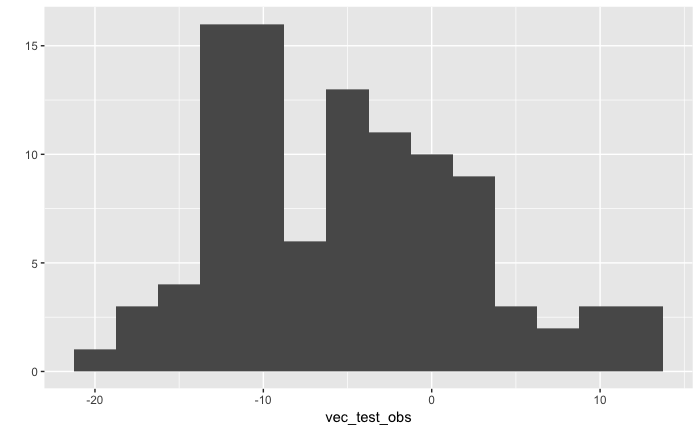

```r
ggplot2::qplot(vec_test_obs, geom = "histogram", binwidth = 2.5)
```

For all elements in `vec_nr_loci`

```r
l_test_obs <- sapply(vec_nr_loci, function(x) return(sample_obs(n_nr_ani, x, list_effectq, n_allele_freq)), USE.NAMES = FALSE)
```

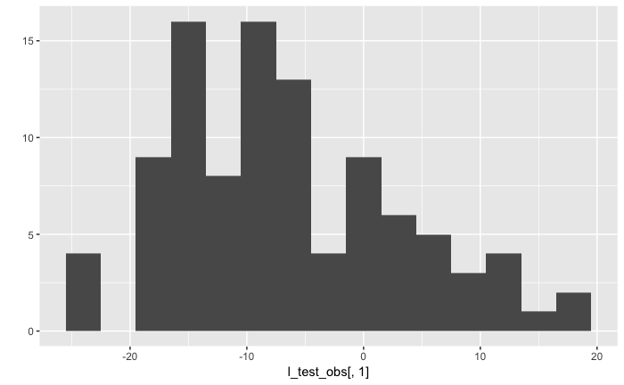

```r
ggplot2::qplot(l_test_obs[,1], geom = "histogram", binwidth = 3)
```

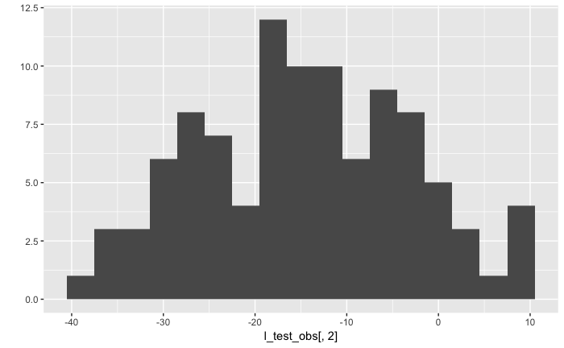

```r
ggplot2::qplot(l_test_obs[,2], geom = "histogram", binwidth = 3)
```

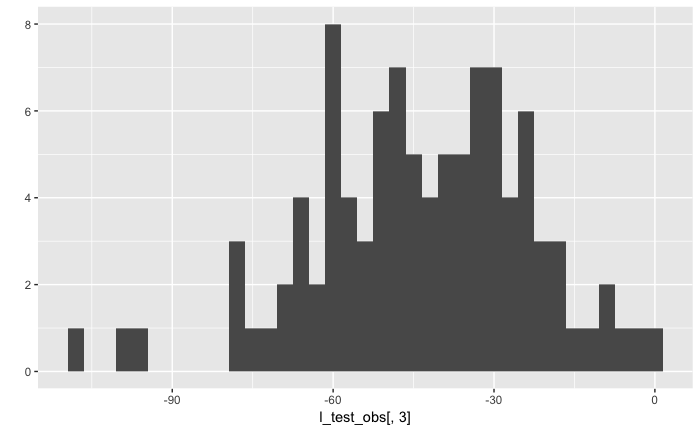

```r
ggplot2::qplot(l_test_obs[,3], geom = "histogram", binwidth = 3)
```

### Answer 2

All requirements can be met with such a tool. The problem is that it takes time to re-familiarize with the tool.

## Using XSim

The data that is needed for this exercise can be generated using XSim. XSim comes as a julia package in a docker container. Hence the question is how can we interact from an RStudio project with the XSim package in the docker container. The following options are available

1. Running everything in a docker container. We are starting with rocker/rstudio and we are adding the XSim package. This can be done in a `Dockerfile` or XSim can be installed interactively. The relevant data from the host-system can be made available as usual via an appropriate directory mount.
2. We are using the docker image qtlrocks/jwas-docker and we are just generating the genomic data inside the docker container.

## Generate Data Using XSim

XSim is run in the docker container `qtlrocks/jwas-docker:mini`. The container is started with

```
docker run -it --rm -p 8888:8888 -v `pwd`:/home/jovyan/work qtlrocks/jwas-docker:mini
```

This mounts the current directory into the container. The julia code used to produce the data is stored in a ipython notebook called `SimulateDataEx04.ipynb`. The data is fixed with formatted and organized in different files. We are reading the data and are storing them in csv files.

| Animal | Sire | Dam |
| --- | --- | --- |
| 1 | NA | NA |
| 2 | NA | NA |
| 3 | NA | NA |
| 4 | NA | NA |
| 5 | NA | NA |
| 6 | 2 | 3 |
| 7 | 1 | 3 |
| 8 | 2 | 5 |
| 9 | 1 | 5 |
| 10 | 7 | 8 |

[output cut: 11 more lines]

## Genomic Information

Genomic information for founders can be generated from an assumed distribution. Then for offspring of two parents we have the following possibilities for a given locus

```r
tbl_inherit <- tibble::tibble(Parent1 = c("", "-1","0","1"),
                              Parent2first = c("-1", "-1", "(-1/0)", "0"),
                              Parent2second = c("0", "(-1/0)", "(-1/0/0/1)", "(0/1)"),
                              Parent2third = c("1", "0", "(0/1)", "1"))
knitr::kable(tbl_inherit)
```

[output not shown]